# warrenkb_PeerCommentary_nirmitin_03

Nirmiti Naik

10/12/2021

```r
library(dplyr)
```

```r
library(ggplot2)
Zombies <- read.csv(header = TRUE, "https://raw.githubusercontent.com/fuzzyatelin/fuzzyatelin.github.io/master/AN588_Fall21/zombies.csv")
head(Zombies)
```

```
##   id first_name last_name gender   height   weight zombies_killed
## 1  1      Sarah    Little Female 62.88951 132.0872              2
## 2  2       Mark    Duncan   Male 67.80277 146.3753              5
## 3  3    Brandon     Perez   Male 72.12908 152.9370              1
## 4  4      Roger   Coleman   Male 66.78484 129.7418              5
## 5  5      Tammy    Powell Female 64.71832 132.4265              4
## 6  6    Anthony     Green   Male 71.24326 152.5246              1
##   years_of_education                           major      age
## 1                  1                medicine/nursing 17.64275
## 2                  3 criminal justice administration 22.58951
## 3                  1                       education 21.91276
## 4                  6                  energy studies 18.19058
## 5                  3                       logistics 21.10399
## 6                  4                  energy studies 21.48355
```

#### Calculate the population mean and standard deviation for each quantitative random variable (height, weight, age, number of zombies killed, and years of education). NOTE: You will not want to use the built in var() and sd() commands as these are for samples

Good job on calculating the means for each variable! I had to check the module pages to find what to use for population standard deviation so I’d suggest doing that because I was really confused til then - NN

```r
mean(Zombies$height)
```

```
## [1] 67.6301
```

```r
mean(Zombies$weight)
```

```
## [1] 143.9075
```

```r
mean(Zombies$age)
```

```
## [1] 20.04696
```

```r
mean(Zombies$zombies_killed)
```

```
## [1] 2.992
```

```r
mean(Zombies$years_of_education)
```

```
## [1] 2.996
```

#### Use {ggplot} to make boxplots of each of these variables by gender

Your plots look so good - I love the colors! - NN

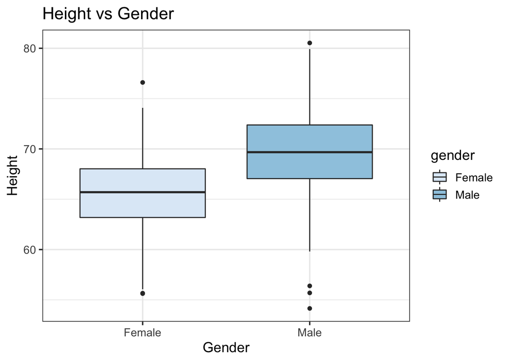

```r
ggplot(Zombies, aes(x=gender, y= height)) +
  geom_boxplot(aes(fill=gender)) +
  scale_fill_brewer(palette="Blues") +
  labs(title="Height vs Gender", x="Gender", y="Height") +
  theme_bw(14)
```

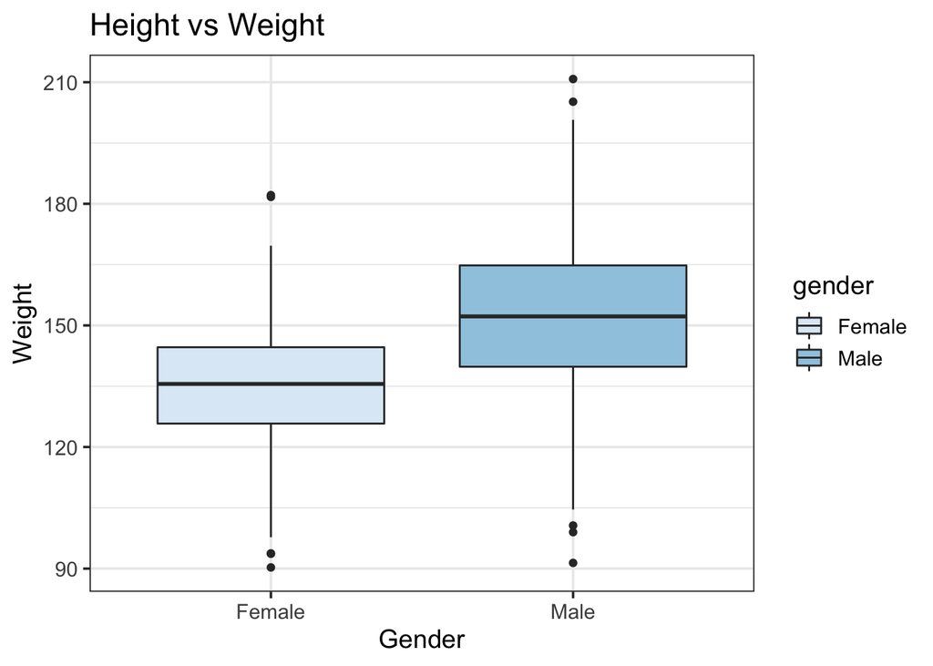

```r
ggplot(Zombies, aes(x=gender, y= weight)) +
  geom_boxplot(aes(fill=gender)) +
  scale_fill_brewer(palette="Blues") +
  labs(title="Height vs Weight", x="Gender", y="Weight") +
  theme_bw(14)
```

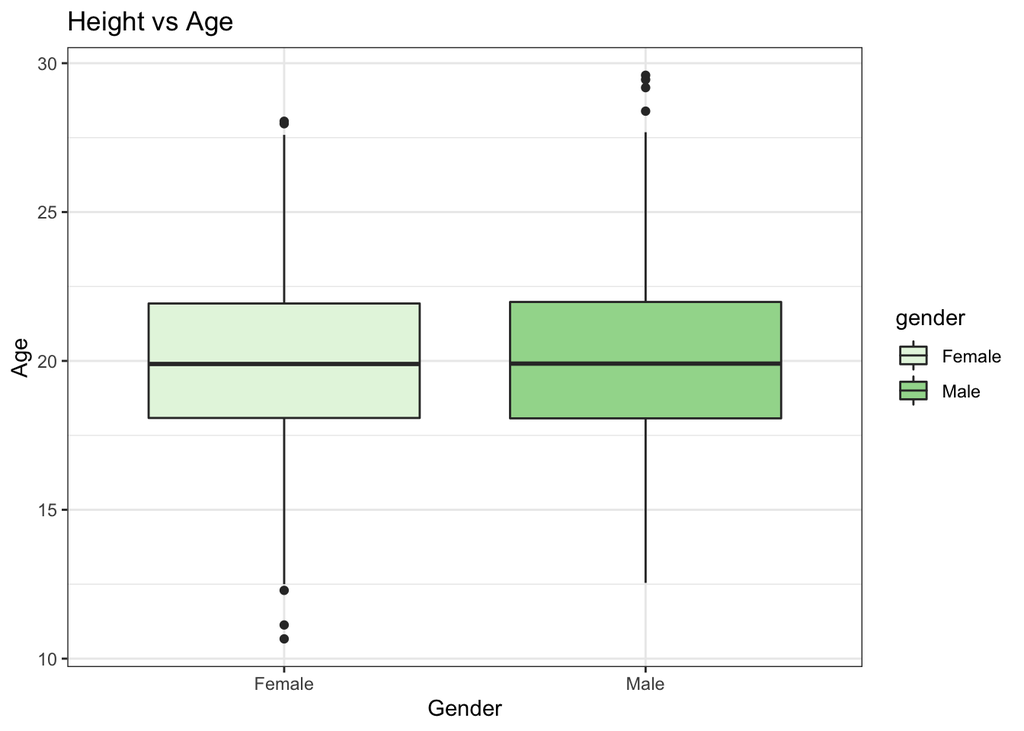

```r
ggplot(Zombies, aes(x=gender, y= age)) +
  geom_boxplot(aes(fill=gender)) +
  scale_fill_brewer(palette="Greens") +
  labs(title="Height vs Age", x="Gender", y="Age") + theme_bw()
```

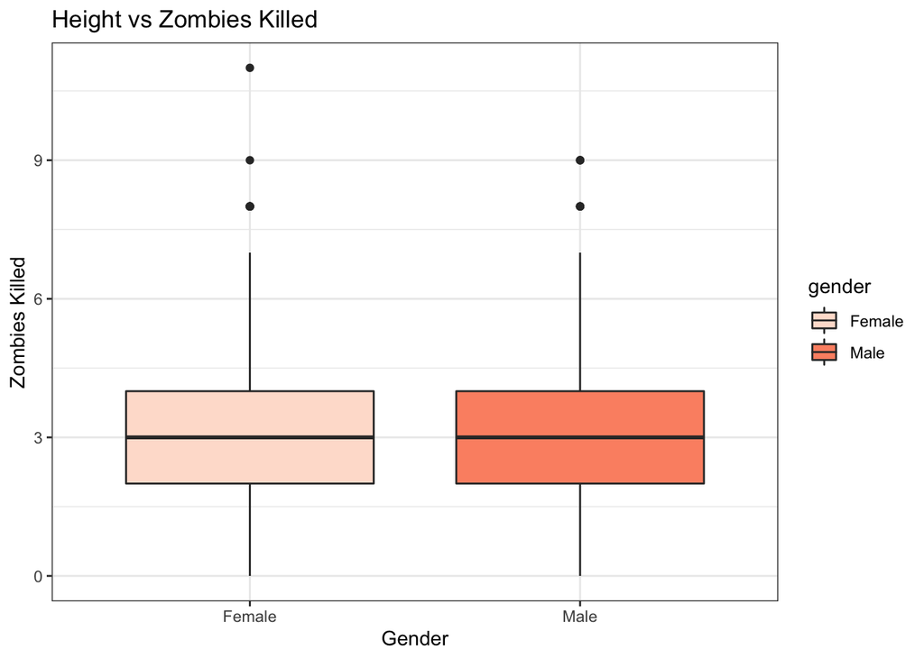

```r
ggplot(Zombies, aes(x=gender, y= zombies_killed)) +
  geom_boxplot(aes(fill=gender)) +
  scale_fill_brewer(palette="Reds") +
  labs(title="Height vs Zombies Killed", x="Gender", y="Zombies Killed") + theme_bw()
```

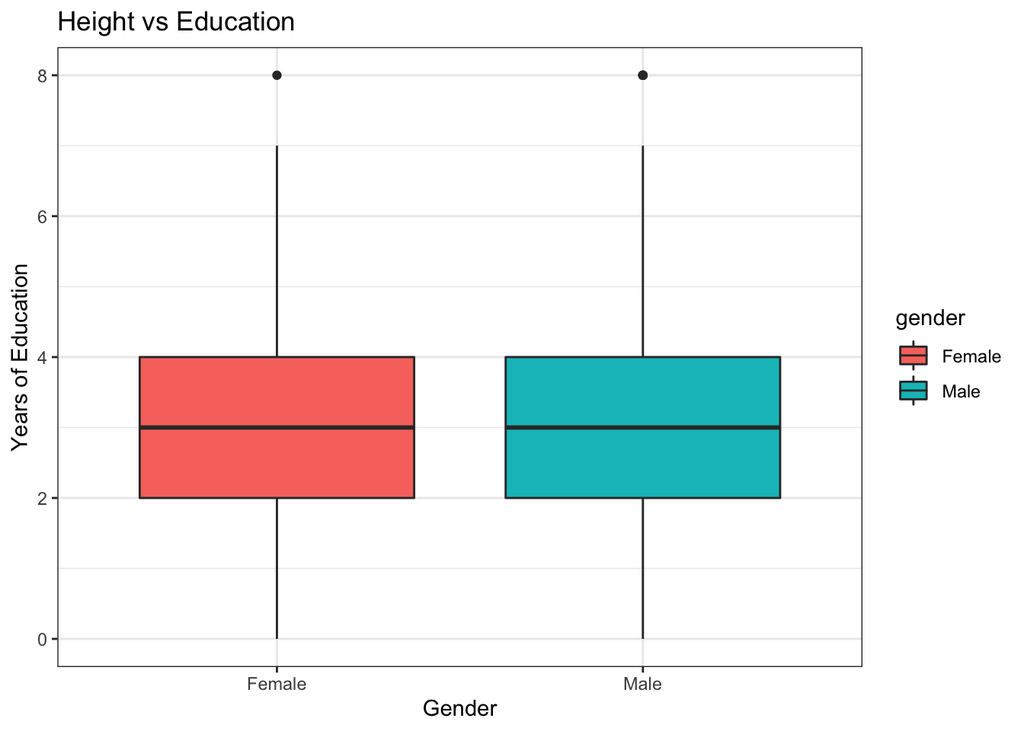

```r
ggplot(Zombies, aes(x=gender, y= years_of_education)) +
  geom_boxplot(aes(fill=gender)) +
  labs(title="Height vs Education", x="Gender", y="Years of Education") + theme_bw()
```

#### Use {ggplot} to make scatterplots of height and weight in relation to age. Do these variables seem to be related? In what way?

I think you should check out the ggplot cheatsheet online - it has the basic format of how to create all the different kinds of plots. I believe the basic format is ggplot(data, aes(x, y )) + geom_point(). Once you do that, commenting on the relationship between these variables should be straight forward. - NN

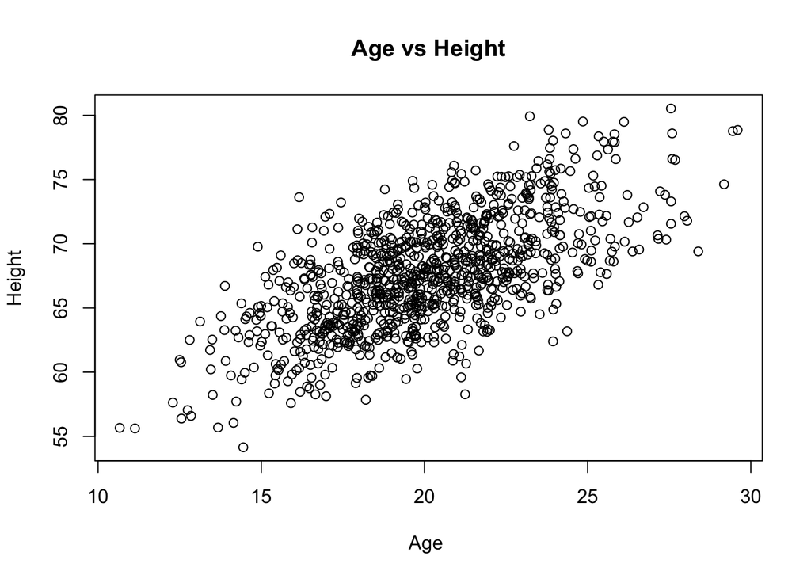

```r
attach(Zombies)
plot(age, height, main="Age vs Height",
   xlab="Age ", ylab="Height")
```

```r
attach(Zombies)
```

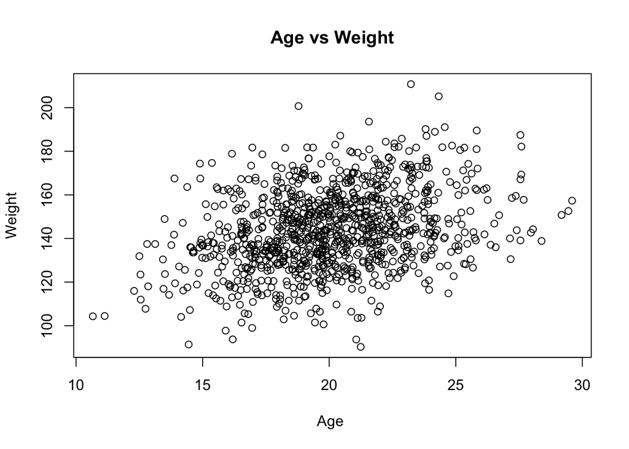

```r
plot(age, weight, main="Age vs Weight",
   xlab="Age ", ylab="Weight")
```

#### Using histograms and Q-Q plots, check whether the quantitative variables seem to be drawn from a normal distribution. Which seem to be and which do not (hint: not all are drawn from the normal distribution)? For those that are not normal, can you determine from which common distribution they are drawn?

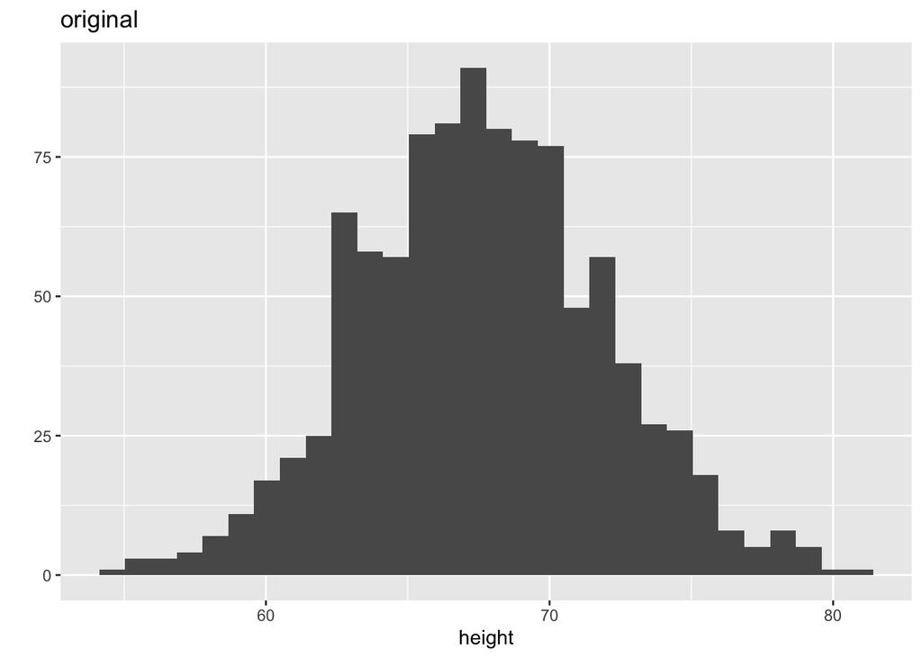

```r
qplot(height, main = "original")
```

```r
shapiro.test(height)
```

```
##
##  Shapiro-Wilk normality test
##
## data:  height
## W = 0.99851, p-value = 0.5631
```

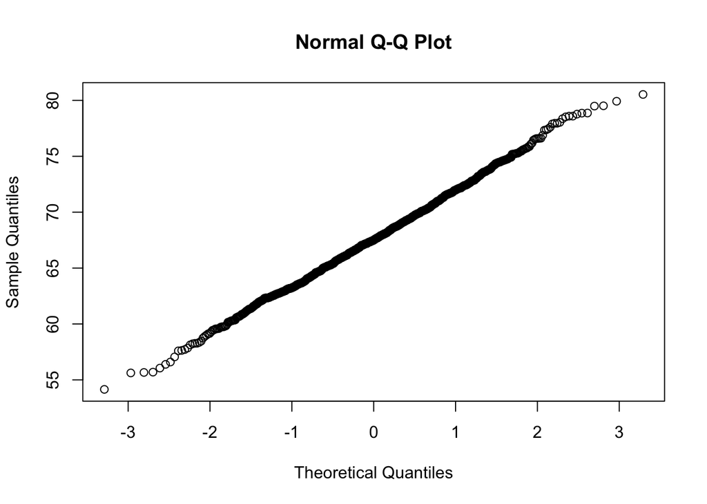

```r
qqnorm(height)
```

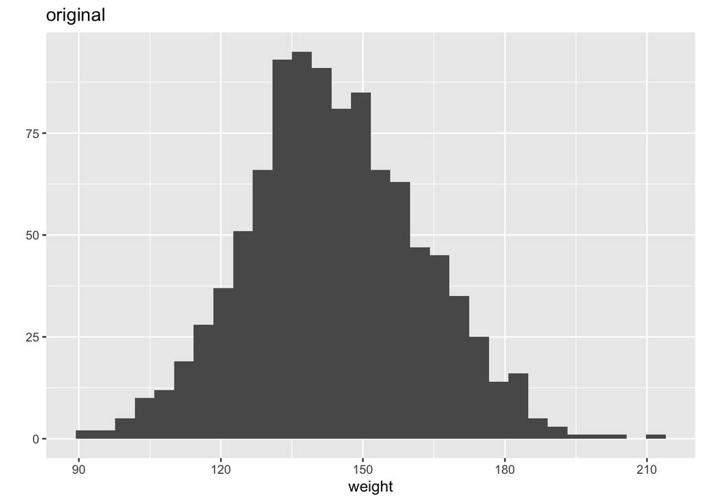

```r
qplot(weight, main = "original")
```

```r
shapiro.test(weight)
```

```
##
##  Shapiro-Wilk normality test
##
## data:  weight
## W = 0.99777, p-value = 0.1997
```

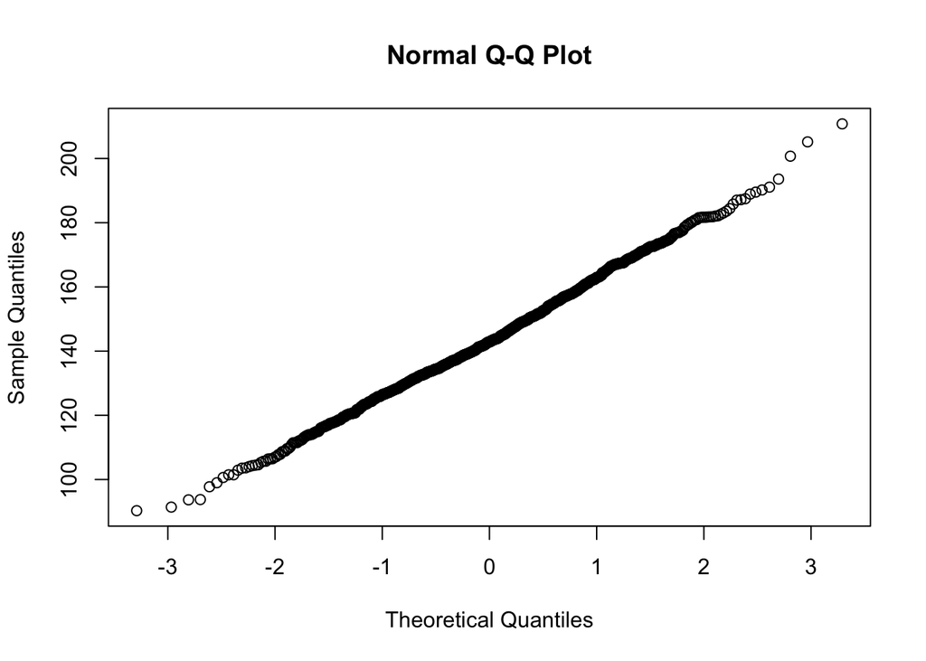

```r
qqnorm(weight)
```

#### Answer: There is a linear realtionship in the Q-Q plot and the graphs are normally distributed.

#### Now use the sample() function to sample ONE subset of 30 zombie survivors (without replacement) from this population and calculate the mean and sample standard deviation for each variable. Also estimate the standard error for each variable, and construct the 95% confidence interval for each mean. Note that for the variables that are not drawn from the normal distribution, you may need to base your estimate of the CIs on slightly different code than for the normal…

```r
set.seed(1)
Sample_30 <- sample_n(Zombies, 30, replace = FALSE)
Sample_30
```

```
##     id  first_name last_name gender   height   weight zombies_killed
## 1  836       Susan   Hawkins Female 69.35963 133.1018              3
## 2  679    Benjamin      Ward   Male 61.95252 139.9611              2
## 3  129      Martin    Wagner   Male 70.26668 154.6746              2
## 4  930       Keith    Wagner   Male 63.24096 132.8480              3
## 5  509       Doris      Lane Female 62.33275 134.0491              3
## 6  471    Jennifer  Williams Female 62.29205 144.9394              2
## 7  299       Kelly     Burke Female 69.91124 145.7389              5
## 8  270 Christopher       Lee   Male 67.64806 130.5163              2
## 9  978      Willie  Richards   Male 64.73728 133.3641              5
## 10 187         Ann      Reid Female 71.02192 141.7984              2
## 11 307        Judy    Peters Female 63.76315 127.8650              4
## 12 597       Linda Patterson Female 63.14829 106.4643              2
## 13 277      Carlos Alexander   Male 75.21887 176.9457              3
## 14 874        Sean    Brooks   Male 68.52690 126.8207              1
```

[output cut: 47 more lines]

```r
mean(Sample_30$age)
```

```
## [1] 19.68657
```

```r
mean(Sample_30$weight)
```

```
## [1] 142.2536
```

```r
mean(Sample_30$zombies_killed)
```

```
## [1] 3.066667
```

```r
mean(Sample_30$years_of_education)
```

```
## [1] 2.966667
```

```r
mean(Sample_30$height)
```

```
## [1] 66.88522
```

```r
sd(Sample_30$age)
```

```
## [1] 2.960476
```

```r
sd(Sample_30$weight)
```

```
## [1] 16.22658
```

```r
sd(Sample_30$height)
```

```
## [1] 3.735037
```

```r
sd(Sample_30$zombies_killed)
```

```
## [1] 1.680175
```

```r
sd(Sample_30$years_of_education)
```

```
## [1] 1.691425
```

```r
Standard_Error <- function(x) {sd(x)/sqrt(length(x))}
Standard_Error(Sample_30$age)
```

```
## [1] 0.5405065
```

```r
Standard_Error(Sample_30$height)
```

```
## [1] 0.6819214
```

```r
Standard_Error(Sample_30$weight)
```

```
## [1] 2.962555
```

```r
Standard_Error(Sample_30$zombies_killed)
```

```
## [1] 0.3067566
```

```r
Standard_Error(Sample_30$years_of_education)
```

```
## [1] 0.3088106
```

#### Now draw 99 more random samples of 30 zombie apocalypse survivors, and calculate the mean for each variable for each of these samples. Together with the first sample you drew, you now have a set of 100 means for each variable (each based on 30 observations), which constitutes a sampling distribution for each variable. What are the means and standard deviations of this distribution of means for each variable? How do the standard deviations of means compare to the standard errors estimated in [5]? What do these sampling distributions look like (a graph might help here)? Are they normally distributed? What about for those variables that you concluded were not originally drawn from a normal distribution?

```r
N <- 99
T <-30
W <- NULL
for (i in 1:N) {
     W[[i]] <- sample(Zombies$height, size = T, replace = FALSE)
}
head(W)
```

```
## [[1]]
##  [1] 62.69921 69.77392 71.27114 69.87253 76.60479 75.19044 73.62638 67.21994
##  [9] 66.39057 71.95173 69.94287 59.56853 72.60485 63.52487 68.01025 57.85084
## [17] 66.27632 67.03964 64.05988 72.60652 69.89447 66.81429 73.29541 70.06512
## [25] 68.82742 69.16849 67.67221 69.31778 80.52980 64.60695
##
## [[2]]
##  [1] 64.61437 70.79582 71.67543 70.03853 69.78112 66.88320 70.99103 63.32658
##  [9] 68.50593 69.43963 66.59400 63.92522 58.23005 69.14784 73.62638 65.07139
## [17] 60.87902 72.49922 59.29313 70.41512 59.95642 69.27720 74.34293 73.35391
## [25] 66.19163 72.78263 63.63477 56.59750 72.39275 72.42975
##
## [[3]]
##  [1] 70.28444 63.08010 64.64341 65.36311 66.44662 69.42668 69.25217 72.60485
##  [9] 62.51217 73.60436 63.19721 65.43688 71.43294 65.25383 62.92221 66.63451
## [17] 67.08054 67.69933 70.18705 75.73562 63.18823 63.41696 66.35267 70.12632
## [25] 65.63107 72.51684 66.11227 74.89581 72.42883 67.17217
##
## [[4]]
##  [1] 67.97952 69.25217 69.87480 66.52055 70.26668 63.70855 67.06186 68.59139
##  [9] 66.16297 65.27007 58.88539 65.95360 70.94190 64.30928 60.77654 63.27806
## [17] 57.59593 66.35689 68.67496 66.64708 68.57275 66.19163 57.05437 71.01284
## [25] 61.98588 69.44316 74.23468 62.88951 64.64341 69.54824
##
## [[5]]
##  [1] 69.42668 59.29313 63.82403 64.08300 69.95512 63.77365 68.68642 64.67957
##  [9] 73.57948 66.58934 67.54954 54.14948 71.99679 72.25866 77.60621 70.75748
## [17] 70.64534 63.53249 74.13331 67.17217 62.54044 75.70883 67.45969 67.10780
## [25] 63.99734 62.07196 76.58644 64.45048 69.11031 69.94287
##
## [[6]]
##  [1] 63.52487 65.08026 71.09236 67.97952 71.59179 68.94033 75.18903 70.42895
##  [9] 71.30298 70.12632 72.98792 70.64534 68.70399 69.11815 62.03725 70.21352
## [17] 70.65569 71.68890 59.70420 74.75869 62.65719 69.00715 68.42884 75.18322
## [25] 70.09183 67.64617 67.44551 65.18479 64.45252 73.02198
```